# Dot-size variance reduces biases in numerical discrimination and estimation tasks

Cory D. Bonn

Véronique Izard

5/05/2017

[figure not shown]

[figure not shown]

## Research Question

Humans can rapidly estimate the number of items in a scene without verbally counting. However, it is unclear what role non-numerical magnitude cues play in calculating the numerical representation.

Do they play a critical role in augmenting accuracy or internal noise levels?

## Background

When estimating numerosity, human subjects overestimate the number of sparse/small dots and underestimate the number of dense/large dots.

When we inject noise into the stimuli to perturb the non-numerical cues that contribute to these biases, what will happen?

If these non-numerical variables provide a noise-reducing cue in the approximate number system, then we should see a decrease in overall accuracy in discrimination tasks or an increase in variance in estimation tasks when their influence is removed.

#### Figure 1.

Densely distributed, large dots (left) are underestimated while sparsely distributed, small dots (right) are overestimated.

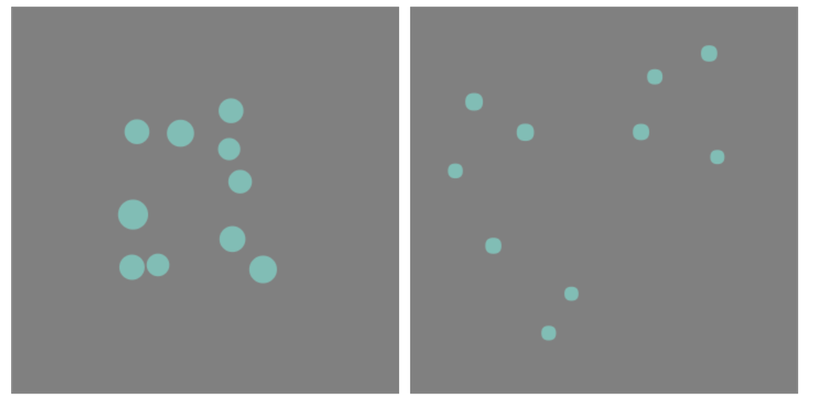

## Design of Experiments

#### Figure 2 - Size variance vevels

Left to right: low to high variance levels used in individual displays.

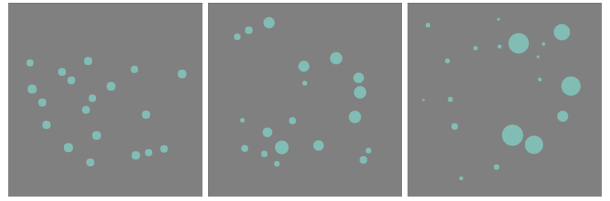

### Tasks

#### Discrimination

Subjects (n = 16) judged which of two sets of dots contained the greater number. The pair was congruent with known bias half of the time; each display contained one dense array and one sparse array created by manipulating total area occupied and the average size of the dots.

#### Estimation

Subjects (n = 23, 2 omitted for not completing task) estimated the number of dots in a single set by indicating a point on a horizontal slider.

## Results - Discrimination

We estimated a Bayesian, multilevel logistic regression with a maximal random-effect structure in rstanarm. We found that injecting variance reduces bias on dense vs. sparse arrays.

#### Figure 3. Model predictions and empirical individual subject means (Means and 95% Credible Intervals).

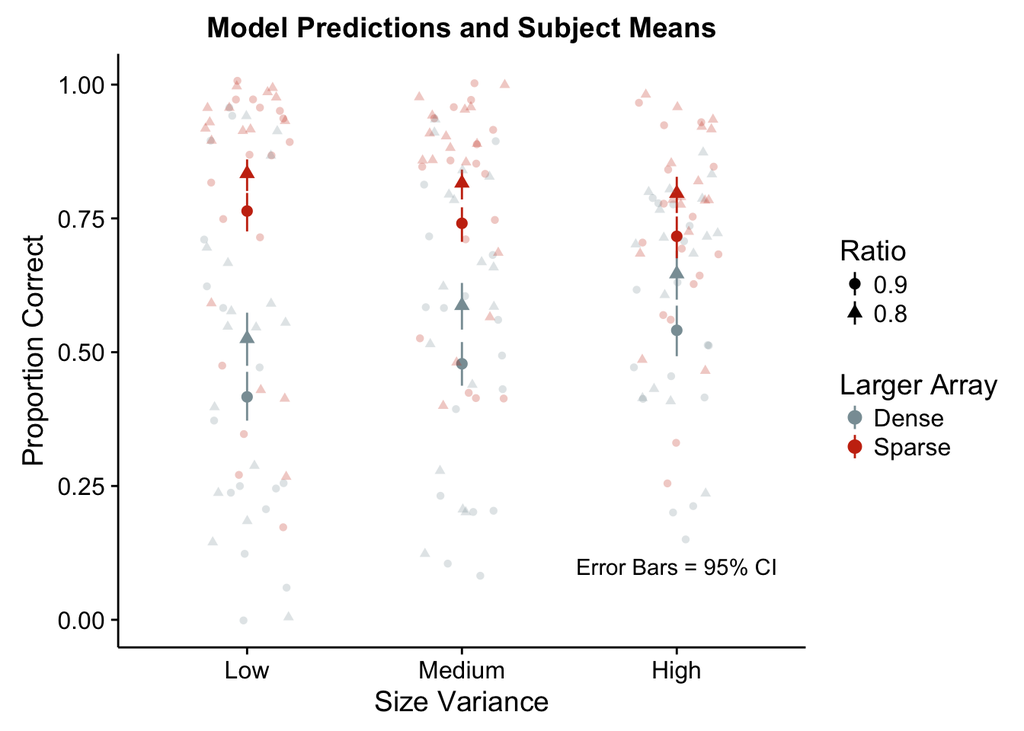

#### Figure 4. Model results: coefficient estimates (Means, 50%, and 95% Credible Intervals).

The most important coefficient to note is that the Dense.vs.Sparse:Size.Variance term is credibly below zero.

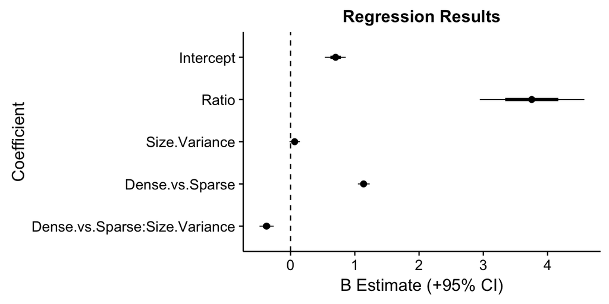

## Results - Estimation

We estimated a Bayesian, multilevel log-linear regression with a maximal random-effect structure. Again, variance reduces density-related bias in estimation.

#### Figure 5. Model predictions (Means and 95% Credible Intervals).

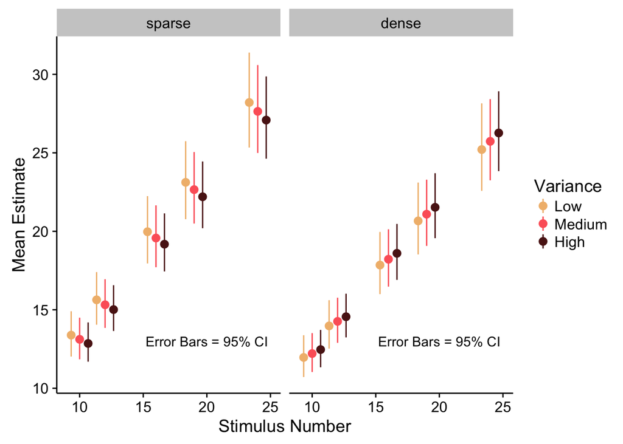

#### Figure 6. Regression model results: coefficient estimates (Means, 50%, and 95% Credible Intervals).

The most important point to note is that the interaction term (Dense.vs.Sparse:Size.Variance) is credibly different from zero. (Note that the interaction is positive here because of a fluke difference in choice of coding for Dense (0.5) vs. Sparse (-0.5).)

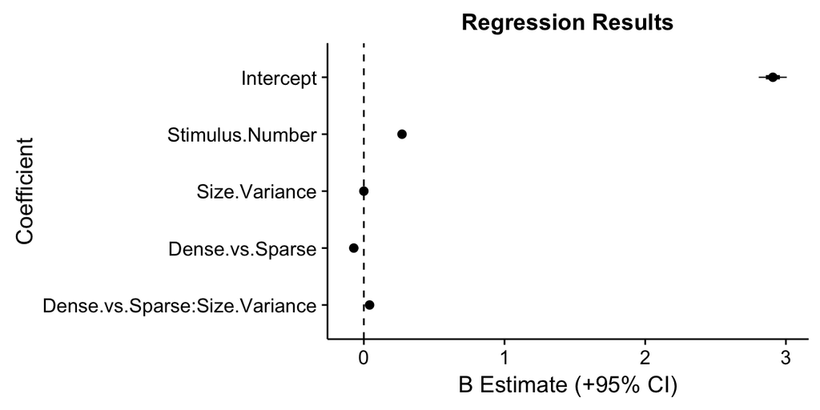

#### Figure 7. Differences in residual SD for low- and high-variance conditions.

The figure on the left displays the estimated standard deviation of subjects’ number estimates in the low and high conditions. The figure on the right displays their difference.

No strong evidence of a difference in estimation dispersion in the high vs. low size-variance conditions.

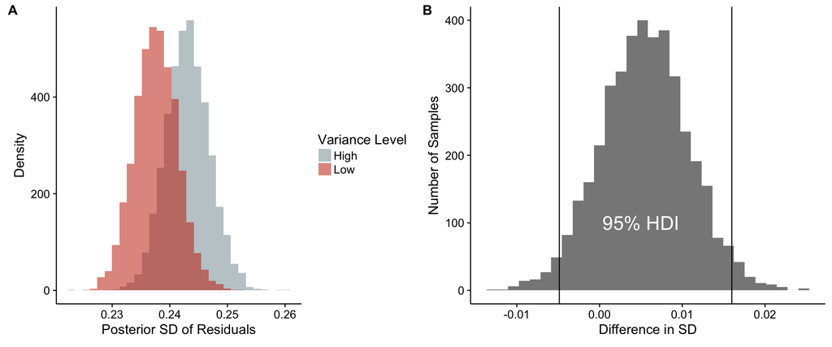

## Discussion

Dot-size variance reduces the influence of global, non-numerical cues such as cumulative surface area and total area occupied, but does not decrease overall accuracy in discrimination nor significantly increase variance in estimation.

## Acknowledgments

ERC Project MathConstruction 263179 to V.I. and Fyssen Postdoctoral Study Grant to C.D.B.

[figure not shown]